# R Final Project - Group 11

08 mayo 2022

## Introduction

- **Dataset:** MiRNA expression in squamous cell carcinoma and adenocarcinoma of the esophagus and associations with survival.
  - Cancerous and noncancerous tissues.
  - Cancer stages.
  - 100 ADC and 70 SCC patients.
  - North American and Japanese cohorts.
  - Other variables (tabacco, alcohol)
- **Objective of the project:** To reproduce the findings of the authors and elaborate on their visualizations.

## Materials and methods

### **Patient data**:

- **GSE13937_series_matrix.txt**
- National Center for Biotechnology Information website (https://www.ncbi.nlm.nih.gov/geo/query/acc.cgi?acc=GSE13937)

### **Microarray information**:

- **A-GEOD-8835.adf.txt** and **A-GEOD-8835_comments.txt**
- European Bioinformatics Institute website (https://www.ebi.ac.uk/arrayexpress/arrays/A-GEOD-8835/)

## Materials and methods

### **Flowchart of the data wrangling and analysis**

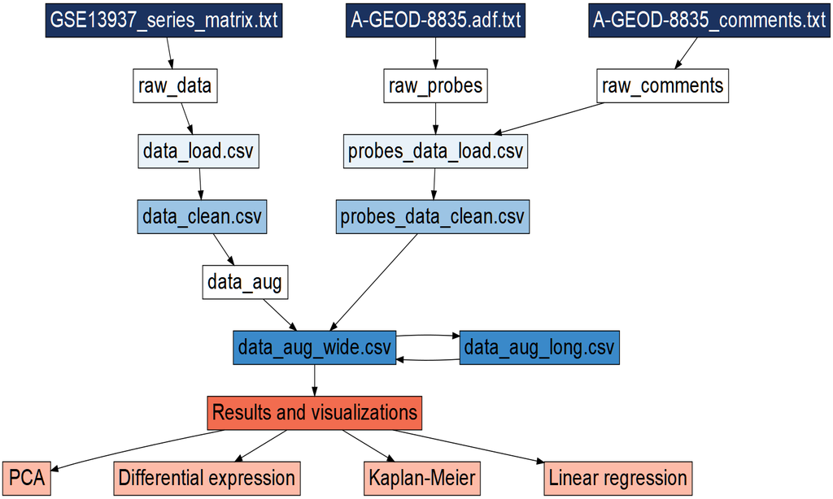

## Results

### **Survival probability for different groups**

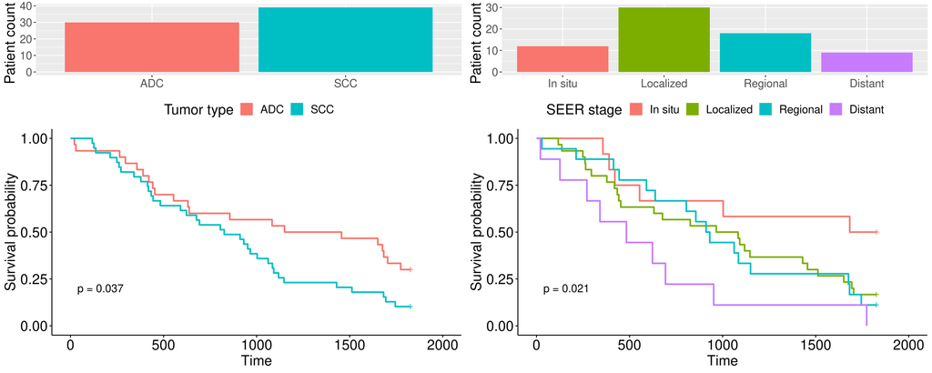

## Results

### **Volcano plots**

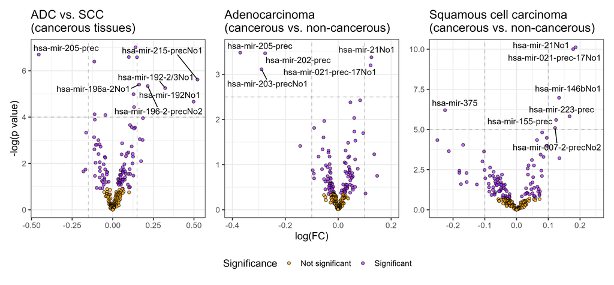